# FigureYa30nomogram_update

**Author(s)**: Dongqiang Zeng, Ying Ge  
**Reviewer(s)**: Yijing Chen  
**Date**: 2026-01-16

## 1 Academic Citation

If you use this code in your work or research, we kindly request that you cite our publication:

Xiaofan Lu, et al. (2025). FigureYa: A Standardized Visualization Framework for Enhancing Biomedical Data Interpretation and Research Efficiency. iMetaMed. https://doi.org/10.1002/imm3.70005

## 2 需求描述 Requirement Description

画出新型nomogram图（d）和对比曲线（f、g）

Draw the new nomogram (d) and comparison curves (f, g)

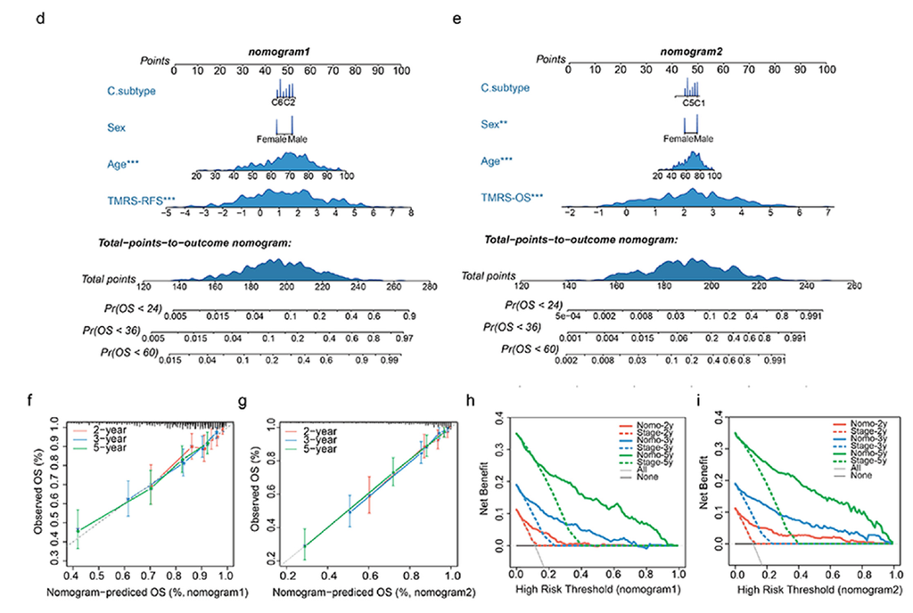

From https://linkinghub.elsevier.com/retrieve/pii/S2352396419301884

Fig. 3. (d–e) Nomograms for predicting the probability of patient mortality based on TMRS-RFS (d), TMRS-OS (e) and clinical variables; (f–g) Plots depict the calibration of nomograms based on TMRS-RFS (f) and TMRS-OS (g) in terms of agreement between predicted and observed 2-year, 3-year, and 5-year outcomes. Nomogram performance is shown by the plot, relative to the 45-degree line, which represents the ideal prediction; (h–i) Decision curve analyses of the nomograms based on TMRS-RFS (h) and TMRS-OS (i) for 2-year, 3-year, and 5-year risk. ADJC, adjuvant chemotherapy; TMRS, tumour microenvironment risk score; RFS, relapse-free survival; OS, overall survival; Pr, probability; Nomo, nomogram.

## 3 应用场景 Application Scenario

列线图（nomogram，诺莫图）是在平面直角坐标系中用一簇互不相交的线段表示多个独立变量之间函数关系的图。

将Logistic回归或Cox回归的结果进行可视化呈现，给出其发病风险或比例风险。

A nomogram is a graph that represents a functional relationship between multiple independent variables in a plane rectangular coordinate system using a cluster of disjointed line segments.

It visualizes the results of a Logistic regression or Cox regression, giving the risk or proportional risk of developing a disease.

## 4 环境设置 Environment Setting

```r
source("install_dependencies.R")
```

```
## Starting R package installation...
## ===========================================
##
## Installing CRAN packages...
## Package already installed: nomogramEx
## Package already installed: regplot
## Package already installed: rms
## Package already installed: survival
##
## ===========================================
## Package installation completed!
## You can now run your R scripts in this directory.
```

```r
library(survival) # 生存分析 survival analysis
library(regplot) # 新型nomogram new nomogram
library(rms) # 经典nomogram classic nomogram
library(nomogramEx) # 输出nomogram公式 output nomogram formula
Sys.setenv(LANGUAGE = "en") #显示英文报错信息 display English error messages
options(stringsAsFactors = FALSE) #禁止chr转成factor prohibit the conversion of chr to factor

# 加载修改后的 regplot 函数，使其支持非交互式环境生成 PDF
# Load modified regplot function to support non-interactive PDF generation
source("regplot_functions_modified.R")
source("regplot_modified.R")
# 如果需要使用原版 regplot，请注释掉上面两行代码
# If you need to use the original regplot, please comment out the above two lines of
```

## 5 输入文件 Input file

```r
pbc <- read.table("easy_input.txt")

pbc$catbili <- cut(pbc$bili, breaks = c(-Inf, 2, 4, Inf),
                   labels=c("low", "medium", "high"))
pbc$died <- pbc$status == 2

head(pbc)
```

```
##          time status trt      age sex ascites hepato spiders edema bili chol
## patient1  400      2   1 58.76523   f       1      1       1   1.0 14.5  261
## patient2 4500      0   1 56.44627   f       0      1       1   0.0  1.1  302
## patient3 1012      2   1 70.07255   m       0      0       0   0.5  1.4  176
## patient4 1925      2   1 54.74059   f       0      1       1   0.5  1.8  244
## patient5 1504      1   2 38.10541   f       0      1       1   0.0  3.4  279
## patient6 2503      2   2 66.25873   f       0      1       0   0.0  0.8  248
##          albumin copper alk.phos    ast trig platelet protime stage catbili
## patient1    2.60    156   1718.0 137.95  172      190    12.2     4    high
## patient2    4.14     54   7394.8 113.52   88      221    10.6     3     low
## patient3    3.48    210    516.0  96.10   55      151    12.0     4     low
## patient4    2.54     64   6121.8  60.63   92      183    10.3     4     low
## patient5    3.53    143    671.0 113.15   72      136    10.9     3  medium
## patient6    3.98     50    944.0  93.00   63       NA    11.0     3     low
##           died
## patient1  TRUE
## patient2 FALSE
## patient3  TRUE
## patient4  TRUE
## patient5 FALSE
## patient6  TRUE
```

## 6 画nomogram Draw nomogram

这里提供两种风格的nomogram画法，用到不同的包

Here are two styles of nomogram drawing, using different packages

### 6.1 经典版 Classic Edition

```r
dd <- datadist(pbc)
options(datadist="dd")
options(na.action="na.delete")
summary(pbc$time)
```

```
##    Min. 1st Qu.  Median    Mean 3rd Qu.    Max.
##      41    1093    1730    1918    2614    4795
```

```r
coxpbc <- cph(formula = Surv(time,died) ~  age + catbili + sex + copper + stage + trt ,data=pbc,x=T,y=T,surv = T,na.action=na.delete)  #,time.inc =2920

print(coxpbc)
```

```
## Frequencies of Missing Values Due to Each Variable
## Surv(time, died)              age          catbili              sex
##                0                0                0                0
##           copper            stage              trt
##              108                6              106
##
## Cox Proportional Hazards Model
##
## cph(formula = Surv(time, died) ~ age + catbili + sex + copper +
##     stage + trt, data = pbc, na.action = na.delete, x = T, y = T,
##     surv = T)
##
##
##                        Model Tests    Discrimination
##                                              Indexes
## Obs       310    LR chi2    161.30    R2       0.413
## Events    124    d.f.            7    R2(7,310)0.392
## Center 4.3475    Pr(> chi2) 0.0000    R2(7,124)0.712
##                  Score chi2 199.30    Dxy      0.672
##                  Pr(> chi2) 0.0000
##
##                Coef    S.E.   Wald Z Pr(>|Z|)
## age             0.0322 0.0091  3.53  0.0004
## catbili=medium  1.4084 0.2489  5.66  <0.0001
## catbili=high    1.8117 0.2493  7.27  <0.0001
## sex=m          -0.2581 0.2818 -0.92  0.3596
## copper          0.0031 0.0011  2.91  0.0036
## stage           0.5431 0.1325  4.10  <0.0001
## trt             0.1106 0.1902  0.58  0.5608
```

```r
surv <- Survival(coxpbc)
surv3 <- function(x) surv(1825,x)
surv4 <- function(x) surv(2920,x)

x <- nomogram(coxpbc,fun = list(surv3,surv4),lp=T,
            funlabel = c('5-year survival Probability','8-year survival Probability'),
            maxscale = 100,fun.at = c(0.95,0.9,0.8,0.7,0.6,0.5,0.4,0.3,0.2,0.1))

pdf("nomogram_classical.pdf",width = 12,height = 10)
plot(x, lplabel="Linear Predictor",
     xfrac=.35,varname.label=TRUE, varname.label.sep="=", ia.space=.2,
     tck=NA, tcl=-0.20, lmgp=0.3,
     points.label='Points', total.points.label='Total Points',
     total.sep.page=FALSE,
     cap.labels=FALSE,cex.var = 1.6,cex.axis = 1.05,lwd=5,
     label.every = 1,col.grid = gray(c(0.8, 0.95)))
dev.off()
```

[figure not shown]

输出公式

output formula

```r
#print(x)
nomogramEx(nomo=x,np=2,digit = 9)
```

```
## $RESULT
## [1] "The equation of each variable as follows:"
##
## [[2]]
## [1] "points = 0 * age ^2 + 1.720070183 * age + -43.001754587"
##
## [[3]]
##     catbili
## 13  0.00000
## 14 75.29340
## 15 96.85421
##
## [[4]]
##         sex
## 16 13.79964
## 17  0.00000
##
## [[5]]
## [1] "points = 0 * copper ^3 + 0 * copper ^2 + 0.166666667 * copper + 0"
##
## [[6]]
##       stage
## 31  0.00000
## 32 29.03326
## 33 58.06653
## 34 87.09979
##
## [[7]]
##         trt
## 35 0.000000
## 36 5.914188
##
## [[8]]
## [1] "5-year survival Probability = 5.9e-08 * points ^3 + -5.1054e-05 * points ^2 + 0.008126192 * points + 0.583874866"
##
## [[9]]
## [1] "8-year survival Probability = 5.9e-08 * points ^3 + -4.3812e-05 * points ^2 + 0.004242289 * points + 0.835039968"
```

## 7 画新型nomogram Draw new nomogram

`regplot`可以交互式调整nomogram，代码更简单，输出的图形更漂亮。

本模块已加载修改后的 `regplot` 函数，使其能够在渲染过程中自动生成 PDF 文件。

`regplot` can interactively adjust the nomogram, the code is simpler, the output graph is more beautiful.

This module loads a modified `regplot` function that can automatically generate PDF files during rendering.

### 7.1 Cox 回归 nomogram Cox Regression Nomogram

```r
pbccox <- coxph(formula = Surv(time,died) ~  age + catbili + sex +
                   copper + stage + trt , data = pbc)

# 生成 Cox 回归 nomogram PDF
# Generate Cox regression nomogram PDF
pdf("nomogram_regplot_cox.pdf", width = 12, height = 8)
regplot(pbccox,
        observation=pbc[2,], #对观测2的六个指标在列线图上进行计分展示，也可以不展示 the six indicators for Observation 2 can be scored and displayed on the nomogram, or they may not be displayed.
        points = TRUE, #如果为FALSE，则显示每个βx贡献的回归分数。否则，贡献将以 0-100 的"点数"刻度表示 If FALSE the regression scores of each βx contribution are shown. Otherwise contributions are represented by a 0-100 "points" scale.
        plots = c("density", #可选"no plot" "density" "boxes" "ecdf" "bars" "boxplot" "violin" "bean" "spikes" optional "no plot" "density" "boxes" "ecdf" "bars" "boxplot" "violin" "bean" "spikes"
                  "boxes"), #可选"no plot" "boxes" "bars" "spikes" optional "no plot" "boxes" "bars" "spikes"
        failtime = c(1095,1825), #预测3年和5年的死亡风险，此处单位是day predict the risk of death over 3 and 5 years, with the unit being days.
        subticks = TRUE,
        clickable = FALSE, # 非交互式环境必须设置为 FALSE / Must be FALSE in non-interactive environment
        prfail = TRUE, #cox回归中需要TRUE TRUE is required in cox regression
        showP = T, #是否展示统计学差异 whether to demonstrate statistical differences
        droplines = F,#观测2示例计分是否画线 Observation 2 example scoring whether or not to draw a line
        rank="range", #rank="range "表示βx的范围，rank="sd "表示βx的标准差 rank="range" is by the range of the βx's, and rank="sd" is by the standard deviation of the βx's.
        interval="confidence") #展示观测的可信区间 demonstrate confidence intervals for observations
```

```
## [[1]]
##   trt Points
## 1   1     36
##
## [[2]]
##   stage Points
## 1     1      0
## 2     2     19
## 3     3     37
## 4     4     56
##
## [[3]]
##   copper Points
## 1      0     27
## 2    100     38
## 3    200     49
## 4    300     59
## 5    400     70
## 6    500     81
## 7    600     92
##
## [[4]]
##      sex Points
## sex2   m     29
## sex1   f     38
##
## [[5]]
##          catbili Points
## catbili1     low     38
## catbili2  medium     86
## catbili3    high    100
##
## [[6]]
##   age Points
## 1  25     10
## 2  35     21
## 3  45     32
## 4  55     43
## 5  65     54
## 6  75     65
##
## [[7]]
##   Total Points Pr( time < 1095 )
## 1          150            0.0069
## 2          200            0.0292
## 3          250            0.1196
## 4          300            0.4215
## 5          350            0.9047
## 6          400            1.0000
```

```r
dev.off()
```

[figure not shown]

### 7.2 逻辑回归 nomogram Logistic Regression Nomogram

```r
## 绘制逻辑回归图，显示几率表和置信区间
## Plot a logistic regression, showing odds scale and confidence interval
pbcglm <- glm(died ~  age + catbili + sex + copper, family = "binomial", data=pbc )

# 生成逻辑回归 nomogram PDF
# Generate logistic regression nomogram PDF
pdf("nomogram_regplot_glm.pdf", width = 10, height = 8)
regplot(pbcglm,
        observation=pbc[1,],
        points = TRUE,
        subticks = TRUE,
        clickable = FALSE, # 非交互式环境必须设置为 FALSE / Must be FALSE in non-interactive environment
        odds = TRUE,
        interval = "confidence")
```

```
## [[1]]
##   copper Points
## 1      0     26
## 2    100     39
## 3    200     51
## 4    300     64
## 5    400     76
## 6    500     89
## 7    600    102
##
## [[2]]
##      sex Points
## sex1   f     38
## sex2   m     47
##
## [[3]]
##          catbili Points
## catbili1     low     38
## catbili2  medium     77
## catbili3    high     93
##
## [[4]]
##    age Points
## 1   25     -2
## 2   30      6
## 3   35     14
## 4   40     22
## 5   45     30
## 6   50     38
## 7   55     46
## 8   60     55
## 9   65     63
## 10  70     71
## 11  75     79
## 12  80     87
##
## [[5]]
##    Total Points Pr( died )
## 1           100    0.03034
## 2           120    0.06589
## 3           140    0.13720
## 4           160    0.26390
## 5           180    0.44700
## 6           200    0.64570
## 7           220    0.80420
## 8           240    0.90250
## 9           260    0.95430
## 10          280    0.97920
## 11          300    0.99070
## 12          320    0.99580
```

```r
dev.off()
```

[figure not shown]

## 8 绘制calibration curve进行验证 Plot calibration curve for validation

采用和nomogram一样的变量进行多因素cox回归

Perform multivariable Cox regression using the same variables as the nomogram

### 8.1 5年 5 years

```r
set.seed(123)  # 设置随机种子以确保结果可重复 / Set seed for reproducibility
f5 <- cph(formula = Surv(time,died) ~  age + catbili + sex + copper +stage + trt,data=pbc,x=T,y=T,surv = T,na.action=na.delete,time.inc = 1825)

#参数m=50表示每组50个样本进行重复计算
#the parameter m=50 means 50 samples in each group for repeated calculations
cal5 <- calibrate(f5, cmethod="KM", method="boot",u=1825,m=50,B=1000)
```

```
## Using Cox survival estimates at 1825 Days
```

```r
pdf("calibration_5y.pdf",width = 8,height = 8)
plot(cal5,
     lwd = 2,#error bar的粗细 thickness of the error bar
     lty = 1,#error bar的类型，可以是0-6 type of the error bar, which can be 0-6.
     errbar.col = c("#2166AC"),#error bar的颜色 color of the error bar
     xlim = c(0,1),ylim= c(0,1),
     xlab = "Nomogram-prediced OS (%)",ylab = "Observed OS (%)",
     cex.lab=1.2, cex.axis=1, cex.main=1.2, cex.sub=0.6) #字的大小 font size
lines(cal5[,c('mean.predicted',"KM")],
      type = 'b', #连线的类型，可以是"p","b","o" type of line, which can be "p", "b", "o".
      lwd = 2, #连线的粗细 thickness of the line
      pch = 16, #点的形状，可以是0-20 shape of the point, which can be 0-20
      col = c("#2166AC")) #连线的颜色 color of the line
mtext("")
box(lwd = 1) #边框粗细 border thickness
abline(0,1,lty = 3, #对角线为虚线 diagonal lines are dashed
       lwd = 2, #对角线的粗细 diagonal thickness
       col = c("#224444")#对角线的颜色 diagonal color
       )
dev.off()
```

[figure not shown]

### 8.2 8年 8 years

```r
set.seed(123)  # 设置随机种子以确保结果可重复 / Set seed for reproducibility
f8 <- cph(formula = Surv(time,died) ~  age + catbili + sex + copper +stage + trt,data=pbc,x=T,y=T,surv = T,na.action=na.delete,time.inc = 2920)
cal8 <- calibrate(f8, cmethod="KM", method="boot",u=2920,m=50,B=1000)
```

```
## Using Cox survival estimates at 2920 Days
```

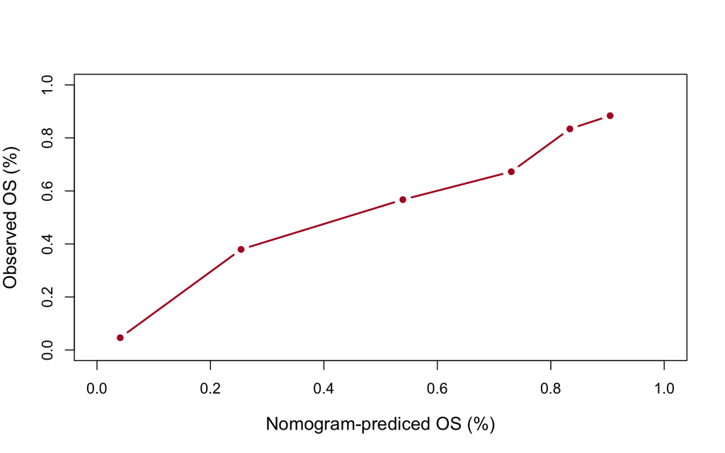

```r
# 手动绘制 calibration 曲线，避免默认连线
# Manually draw calibration curve to avoid default connecting lines
plot(cal8[,c('mean.predicted',"KM")],
     type = 'b',
     pch = 16,
     lwd = 2,
     col = c("#B2182B"),
     xlim = c(0,1),ylim= c(0,1),
     xlab = "Nomogram-prediced OS (%)",ylab = "Observed OS (%)",
     cex.lab=1.2,cex.axis=1)
```

[figure not shown]

```r
# 添加误差棒 - 使用 Hmisc::errbar 的正确参数格式
errbar(x = cal8[,1], y = cal8[,2], yplus = cal8[,4], yminus = cal8[,3],
        col = c("#B2182B"), lwd = 2, lty = 1)
box(lwd = 1)
abline(0,1,lty= 3, lwd = 2, col =c("#224444"))
```

### 8.3 同时展示两条curve Show two curves at the same time

```r
pdf("calibration_compare.pdf",width = 8,height = 8)
plot(cal5,lwd = 2,lty = 0,errbar.col = c("#2166AC"),
     bty = "l", #只画左边和下边框 draw only the left and lower borders
     xlim = c(0,1),ylim= c(0,1),
     xlab = "Nomogram-prediced OS (%)",ylab = "Observed OS (%)",
     col = c("#2166AC"),
     cex.lab=1.2,cex.axis=1, cex.main=1.2, cex.sub=0.6)
lines(cal5[,c('mean.predicted',"KM")],
      type = 'b', lwd = 1, col = c("#2166AC"), pch = 16)
mtext("")

plot(cal8,lwd = 2,lty = 0,errbar.col = c("#B2182B"),
     xlim = c(0,1),ylim= c(0,1),col = c("#B2182B"),add = T)
lines(cal8[,c('mean.predicted',"KM")],
      type = 'b', lwd = 1, col = c("#B2182B"), pch = 16)

abline(0,1, lwd = 2, lty = 3, col = c("#224444"))

legend("topleft", #图例的位置 location of the legend
       legend = c("5-year","8-year"), #图例文字 legend text
       col =c("#2166AC","#B2182B"), #图例线的颜色，与文字对应 color of the legend line, corresponding to the text
       lwd = 2,#图例中线的粗细 thickness of lines in the legend
       cex = 1.2,#图例字体大小 legend font size
       bty = "n")#不显示图例边框 legend border not displayed
dev.off()
```

[figure not shown]

## 9 更新要点 Update Notes

修改 `regplot` 包的源代码，使其能够在 R Markdown 渲染时自动生成 PDF 文件。

This module has modified the source code of the `regplot` package to enable automatic PDF generation during R Markdown rendering.